# Assignment 2: Spatial Analysis and Visualization

Healthcare Access and Equity in Pennsylvania

Author

Isabelle Li

Published

December 11, 2025

## Assignment Overview

**Learning Objectives:**

- Apply spatial operations to answer policy-relevant research questions
- Integrate census demographic data with spatial analysis
- Create publication-quality visualizations and maps
- Work with spatial data from multiple sources
- Communicate findings effectively for policy audiences

## Part 1: Healthcare Access for Vulnerable Populations

### Research Question

**Which Pennsylvania counties have the highest proportion of vulnerable populations (elderly + low-income) living far from hospitals?**

Your analysis should identify counties that should be priorities for healthcare investment and policy intervention.

### Required Analysis Steps

Complete the following analysis, documenting each step with code and brief explanations:

#### Step 1: Data Collection (5 points)

Load the required spatial data:

- Pennsylvania county boundaries
- Pennsylvania hospitals (from lecture data)
- Pennsylvania census tracts

#### Step 2: Get Demographic Data

Use `tidycensus` to download tract-level demographic data for Pennsylvania.

**Required variables:**

- Total population
- Median household income
- Population 65 years and over (you may need to sum multiple age categories)

**Your Task:**

```r
# Get demographic data from ACS

Sys.getenv("CENSUS_API_KEY")
```

```
[1] ""
```

```r
basic_vars <- c(total_pop = "B01003_001", medhhinc = "B19013_001")

acs_basic <- get_acs(
  geography = "tract",
  state     = "PA",
  survey    = "acs5",
  year      = 2023,
  variables = basic_vars,
  geometry  = FALSE,
  output    = "wide"
)%>%
  transmute(
    GEOID,
    total_pop = total_popE,
    medhhinc  = medhhincE
  )

age65_vars <- c(
  "B01001_020","B01001_021","B01001_022","B01001_023","B01001_024","B01001_025",
  "B01001_044","B01001_045","B01001_046","B01001_047","B01001_048","B01001_049"
)

acs_65 <- get_acs(
  geography = "tract",
  state     = "PA",
  survey    = "acs5",
  year      = 2023,
  variables = age65_vars,
  geometry  = FALSE
) %>%
  group_by(GEOID) %>%
  summarise(pop65 = sum(estimate, na.rm = TRUE), .groups = "drop")

acs_tract <- acs_basic %>%
  left_join(acs_65, by = "GEOID")

head(acs_tract)
```

```
# A tibble: 6 × 4
  GEOID       total_pop medhhinc pop65
  <chr>           <dbl>    <dbl> <dbl>
1 42001030101      2666    82716   577
2 42001030103      2414   111227   570
3 42001030104      3417    66848   858
4 42001030200      5379    72431  1070
5 42001030300      4390    84643   782
6 42001030400      5557    97694  1231
```

```r
# Join to tract boundaries
tracts_pa <- tracts(state = "PA", year = 2023, cb = TRUE, class = "sf")

tracts_demog <- tracts_pa %>%
  left_join(acs_tract, by = "GEOID")

names(tracts_demog)
```

```
 [1] "STATEFP"    "COUNTYFP"   "TRACTCE"    "GEOIDFQ"    "GEOID"
 [6] "NAME"       "NAMELSAD"   "STUSPS"     "NAMELSADCO" "STATE_NAME"
[11] "LSAD"       "ALAND"      "AWATER"     "total_pop"  "medhhinc"
[16] "pop65"      "geometry"
```

```r
nrow(tracts_demog)
```

```
[1] 3445
```

```r
summary(tracts_demog$pop65)
```

```
   Min. 1st Qu.  Median    Mean 3rd Qu.    Max.
    0.0   429.0   665.0   718.8   945.0  2541.0
```

**Questions to answer:**

- What year of ACS data are you using? [I’m using the 2019–2023 5-year ACS data]
- How many tracts have missing income data?

```r
sum(is.na(tracts_demog$medhhinc))
```

```
[1] 65
```

- What is the median income across all PA census tracts?

```r
median(tracts_demog$medhhinc, na.rm = TRUE)
```

```
[1] 72943.5
```

#### Step 3: Define Vulnerable Populations

Identify census tracts with vulnerable populations based on TWO criteria:

1. Low median household income (choose an appropriate threshold)
2. Significant elderly population (choose an appropriate threshold)

**Your Task:**

```r
# Filter for vulnerable tracts based on your criteria
tracts_demog <- tracts_demog %>%
  mutate(
    pct65 = 100 * pop65 / total_pop
  )

income_threshold <- median(tracts_demog$medhhinc, na.rm = TRUE)
elderly_threshold <- quantile(tracts_demog$pct65, 0.75, na.rm = TRUE)

income_threshold
```

```
[1] 72943.5
```

```r
elderly_threshold
```

```
    75%
23.5149
```

```r
vulnerable_tracts <- tracts_demog %>%
  filter(
    medhhinc < income_threshold,
    pct65 > elderly_threshold
  )

nrow(vulnerable_tracts)
```

```
[1] 422
```

**Questions to answer:**

- What income threshold did you choose and why?

[We defined low-income tracts as those with a median household income below $72,943.5, which is the statewide median income across all Pennsylvania census tracts. This threshold was chosen because the median reflects the central tendency of income distribution and aligns with a relative, within-state definition of economic disadvantage.]

- What elderly population threshold did you choose and why?

[We defined elderly-heavy tracts as those with more than 23.5% of residents aged 65 and older, corresponding to the 75th percentile of the elderly population distribution. This threshold identifies tracts where the elderly population is significantly higher than typical statewide levels, focusing attention on areas with concentrated aging populations.]

- How many tracts meet your vulnerability criteria?

[422 tracts meet both criteria (low income and high elderly population).]

- What percentage of PA census tracts are considered vulnerable by your definition?

[Out of 3,445 tracts statewide, about 12.2% (422 / 3,445 × 100) are classified as vulnerable under our definition.]

#### Step 4: Calculate Distance to Hospitals

For each vulnerable tract, calculate the distance to the nearest hospital.

**Your Task:**

```r
# Transform to appropriate projected CRS

target_crs <- 5070

vulnerable_p <- st_transform(vulnerable_tracts, target_crs)
hospitals_p  <- st_transform(hospitals,        target_crs)

vul_centroids <- st_centroid(vulnerable_p)

nearest_idx <- st_nearest_feature(vul_centroids, hospitals_p)
nearest_dist_m <- st_distance(vul_centroids, hospitals_p[nearest_idx, ], by_element = TRUE)

dist_miles <- set_units(nearest_dist_m, "mi")
dist_miles_num <- as.numeric(dist_miles)

# Calculate distance from each tract centroid to nearest hospital

vulnerable_with_dist <- vulnerable_p %>%
  mutate(
    nearest_hosp_id = nearest_idx,
    dist_miles = dist_miles_num
  )

summary(vulnerable_with_dist$dist_km)
```

[output not shown]

```
Length  Class   Mode
     0   NULL   NULL
```

```r
n_far_over_15mi <- sum(vulnerable_with_dist$dist_miles > 15, na.rm = TRUE)

top_farthest <- vulnerable_with_dist %>%
  arrange(desc(dist_miles)) %>%
  dplyr::select(GEOID, total_pop, medhhinc, pct65, dist_miles) %>%
  head(10)

cat("\nVulnerable tracts:", nrow(vulnerable_with_dist),
    "\nNumber > 15 miles from nearest hospital:", n_far_over_15mi, "\n")
```

```
Vulnerable tracts: 422
Number > 15 miles from nearest hospital: 25
```

```r
top_farthest
```

```
Simple feature collection with 10 features and 5 fields
Geometry type: MULTIPOLYGON
Dimension:     XY
Bounding box:  xmin: 1427375 ymin: 2043196 xmax: 1754030 ymax: 2243700
Projected CRS: NAD83 / Conus Albers
         GEOID total_pop medhhinc    pct65 dist_miles
1  42103950104      2805    66576 32.08556   28.98276
2  42113960102      2005    59100 25.98504   27.76385
3  42033330700      2103    55969 23.58535   25.64808
4  42097082300      4953    72733 23.64224   20.13255
5  42083420800      3682    72564 24.38892   20.10985
6  42113960201      1672    66379 31.81818   19.96396
7  42043025300      4009    57260 27.16388   19.31860
8  42023960200      2470    58633 33.03644   19.31279
9  42119090201      1898    67546 25.50053   18.84035
10 42061951200      4531    59528 26.04282   18.67494
                         geometry
1  MULTIPOLYGON (((1744270 224...
2  MULTIPOLYGON (((1604264 222...
3  MULTIPOLYGON (((1456442 214...
4  MULTIPOLYGON (((1587383 211...
5  MULTIPOLYGON (((1427375 222...
6  MULTIPOLYGON (((1576880 222...
7  MULTIPOLYGON (((1585131 210...
8  MULTIPOLYGON (((1447968 219...
9  MULTIPOLYGON (((1548439 213...
10 MULTIPOLYGON (((1504805 204...
```

**Requirements:**

- Use an appropriate projected coordinate system for Pennsylvania
- Calculate distances in miles
- Explain why you chose your projection

**Questions to answer:**

- What is the average distance to the nearest hospital for vulnerable tracts?

```r
mean(vulnerable_with_dist$dist_miles, na.rm = TRUE)
```

```
[1] 5.858657
```

- What is the maximum distance?

[28.98]

- How many vulnerable tracts are more than 15 miles from the nearest hospital?

[25 Tracts]

#### Step 5: Identify Underserved Areas

Define “underserved” as vulnerable tracts that are more than 15 miles from the nearest hospital.

**Your Task:**

```r
# Create underserved variable

vulnerable_with_dist <- vulnerable_with_dist %>%
  mutate(
    underserved = ifelse(dist_miles > 15, TRUE, FALSE)
  )

n_underserved <- sum(vulnerable_with_dist$underserved, na.rm = TRUE)
pct_underserved <- round(n_underserved / nrow(vulnerable_with_dist) * 100, 1)

cat("Underserved tracts:", n_underserved,
    "out of", nrow(vulnerable_with_dist),
    "(", pct_underserved, "% )\n")
```

```
Underserved tracts: 25 out of 422 ( 5.9 % )
```

```r
underserved_tracts <- vulnerable_with_dist %>%
  filter(underserved == TRUE)

underserved_by_county <- underserved_tracts %>%
  mutate(county_fips = substr(GEOID, 1, 5)) %>%
  group_by(county_fips) %>%
  summarise(n_underserved = n())

head(underserved_by_county)
```

```
Simple feature collection with 6 features and 2 fields
Geometry type: GEOMETRY
Dimension:     XY
Bounding box:  xmin: 1272296 ymin: 2103929 xmax: 1615649 ymax: 2259518
Projected CRS: NAD83 / Conus Albers
# A tibble: 6 × 3
  county_fips n_underserved                                             geometry
  <chr>               <int>                                       <GEOMETRY [m]>
1 42015                   1 MULTIPOLYGON (((1595449 2251631, 1595948 2252177, 1…
2 42023                   2 POLYGON ((1447377 2194151, 1447520 2194167, 1447250…
3 42033                   3 MULTIPOLYGON (((1427629 2125464, 1427205 2127780, 1…
4 42039                   1 MULTIPOLYGON (((1273860 2178170, 1273325 2181453, 1…
5 42043                   1 MULTIPOLYGON (((1585131 2109648, 1585226 2110182, 1…
6 42053                   1 MULTIPOLYGON (((1359123 2169199, 1359918 2169341, 1…
```

**Questions to answer:**

- How many tracts are underserved?

[25 Tracts]

- What percentage of vulnerable tracts are underserved?

[5.9%]

- Does this surprise you? Why or why not?

[No — because healthcare facilities are concentrated in urban regions, while the underserved tracts are primarily rural and sparsely populated, though small in number, they represent significant accessibility challenges.]

#### Step 6: Aggregate to County Level

Use spatial joins and aggregation to calculate county-level statistics about vulnerable populations and hospital access.

**Your Task:**

```r
# Spatial join tracts to counties

vulnerable_with_dist <- vulnerable_with_dist %>% mutate(vulnerable = TRUE)

county_stats <- vulnerable_with_dist %>%
  st_drop_geometry() %>%
  mutate(county_fips5 = substr(GEOID, 1, 5)) %>%
  group_by(county_fips5) %>%
  summarise(
    n_vulnerable     = n(),
    n_underserved    = sum(underserved, na.rm = TRUE),
    pct_underserved  = 100 * n_underserved / n_vulnerable,
    mean_dist_miles  = mean(dist_miles, na.rm = TRUE),
    vuln_pop_65      = sum(pop65, na.rm = TRUE),
    .groups = "drop"
  )

counties_keyed <- counties %>%
  mutate(
    FIPS_COUNT = as.character(FIPS_COUNT),
    county_fips5 = paste0("42", str_pad(FIPS_COUNT, width = 3, side = "left", pad = "0"))
  )

counties_summary <- counties_keyed %>%
  left_join(county_stats, by = "county_fips5")

out_tbl <- counties_summary %>%
  st_drop_geometry() %>%
  dplyr::select(COUNTY_NAM, county_fips5, n_vulnerable, n_underserved,
         pct_underserved, mean_dist_miles, vuln_pop_65) %>%
  arrange(desc(n_underserved), desc(pct_underserved))

head(out_tbl, 10)
```

```
   COUNTY_NAM county_fips5 n_vulnerable n_underserved pct_underserved
1    SULLIVAN        42113            3             3       100.00000
2  CLEARFIELD        42033            4             3        75.00000
3        PIKE        42103            5             3        60.00000
4     CAMERON        42023            2             2       100.00000
5  HUNTINGDON        42061            6             2        33.33333
6      FOREST        42053            1             1       100.00000
7    BRADFORD        42015            2             1        50.00000
8       UNION        42119            3             1        33.33333
9     DAUPHIN        42043            3             1        33.33333
10     MONROE        42089            3             1        33.33333
   mean_dist_miles vuln_pop_65
1        21.532867        1379
2        14.670008        3384
3        17.830823        2815
4        18.934088        1320
5        13.493329        4185
6        18.040637         838
7        14.023367        2413
8         7.997835        3565
9        10.668150        3181
10        6.976864        2532
```

**Required county-level statistics:**

- Number of vulnerable tracts
- Number of underserved tracts
- Percentage of vulnerable tracts that are underserved
- Average distance to nearest hospital for vulnerable tracts
- Total vulnerable population

**Questions to answer:**

- Which 5 counties have the highest percentage of underserved vulnerable tracts?

[Sullivan County, Cameron County, Forest County, Clearfield County, Pike County]

#### Step 7: Create Summary Table

Create a professional table showing the top 10 priority counties for healthcare investment.

**Your Task:**

```r
# Create and format priority counties table

priority_table <- counties_summary %>%
  sf::st_drop_geometry() %>%
  dplyr::select(
    COUNTY_NAM, county_fips5, n_vulnerable, n_underserved,
    pct_underserved, mean_dist_miles, vuln_pop_65
  ) %>%
  dplyr::mutate(
    priority_score = vuln_pop_65 * (pct_underserved / 100)
  ) %>%
  dplyr::arrange(dplyr::desc(priority_score)) %>%
  dplyr::transmute(
    County = COUNTY_NAM,
    `Vulnerable Tracts`   = n_vulnerable,
    `Underserved Tracts`  = n_underserved,
    `% Underserved`       = paste0(round(pct_underserved %||% 0, 1), "%"),
    `Avg Distance (mi)`   = round(mean_dist_miles, 1),
    `Vulnerable Pop (65+)`= scales::comma(round(vuln_pop_65)),
    `Priority Score`      = scales::comma(round(priority_score))
  ) %>%
  head(10)

knitr::kable(
  priority_table,
  caption = "Top 10 Priority Counties for Healthcare Investment in Pennsylvania",
  align = "lcccccc"
)
```

Top 10 Priority Counties for Healthcare Investment in Pennsylvania

| County | Vulnerable Tracts | Underserved Tracts | % Underserved | Avg Distance (mi) | Vulnerable Pop (65+) | Priority Score |
| --- | --- | --- | --- | --- | --- | --- |
| CLEARFIELD | 4 | 3 | 75% | 14.7 | 3,384 | 2,538 |
| PIKE | 5 | 3 | 60% | 17.8 | 2,815 | 1,689 |
| HUNTINGDON | 6 | 2 | 33.3% | 13.5 | 4,185 | 1,395 |
| SULLIVAN | 3 | 3 | 100% | 21.5 | 1,379 | 1,379 |
| LANCASTER | 5 | 1 | 20% | 9.1 | 6,691 | 1,338 |
| CAMERON | 2 | 2 | 100% | 18.9 | 1,320 | 1,320 |
| BRADFORD | 2 | 1 | 50% | 14.0 | 2,413 | 1,206 |
| UNION | 3 | 1 | 33.3% | 8.0 | 3,565 | 1,188 |
| DAUPHIN | 3 | 1 | 33.3% | 10.7 | 3,181 | 1,060 |
| MCKEAN | 5 | 1 | 20% | 11.1 | 4,449 | 890 |

**Requirements:**

- Use `knitr::kable()` or similar for formatting
- Include descriptive column names
- Format numbers appropriately (commas for population, percentages, etc.)
- Add an informative caption
- Sort by priority (you decide the metric)

## Part 2: Comprehensive Visualization

Using the skills from Week 3 (Data Visualization), create publication-quality maps and charts.

### Map 1: County-Level Choropleth

Create a choropleth map showing healthcare access challenges at the county level.

**Your Task:**

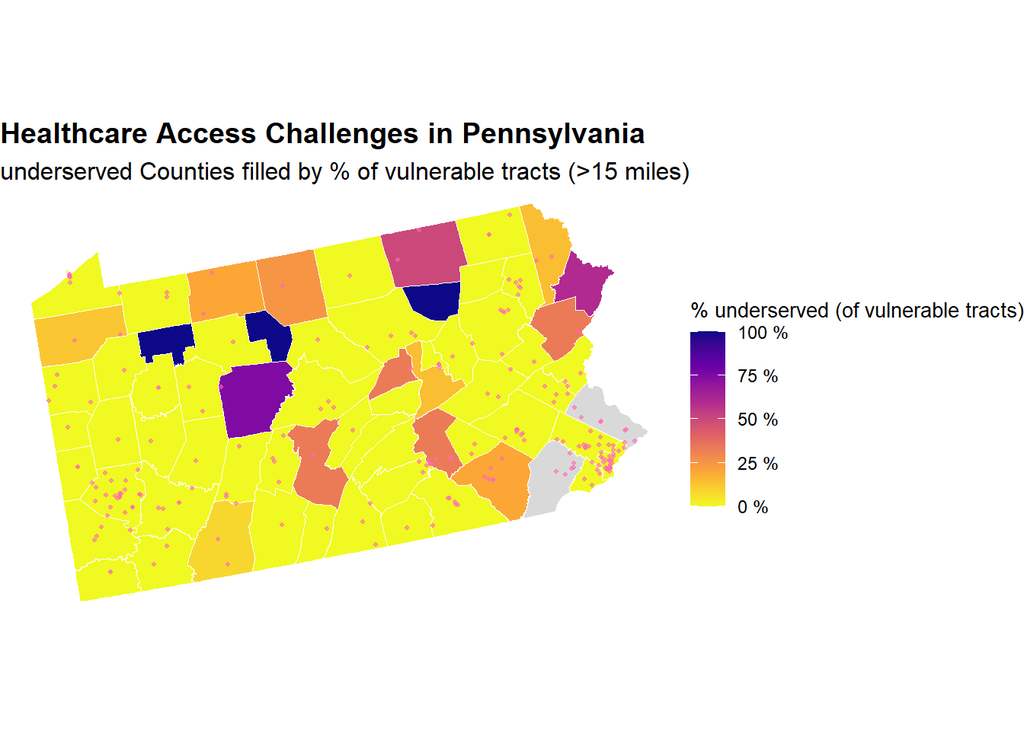

```r
# Create county-level access map

counties_map  <- st_transform(counties_summary, 5070)
hospitals_map <- st_transform(hospitals,       st_crs(counties_map))

ggplot() +
  geom_sf(data = counties_map,
          aes(fill = pct_underserved),
          color = "white", linewidth = 0.2) +
  geom_sf(data = hospitals_map,
          color = "hotpink", alpha = 0.6, size = 0.7) +
  scale_fill_viridis_c(
    option = "C", direction = -1,
    limits = c(0, 100),
    labels = label_number(accuracy = 1, suffix = " %"),
    name = "% underserved (of vulnerable tracts)",
    na.value = "grey85"
  ) +
  labs(
    title = "Healthcare Access Challenges in Pennsylvania",
    subtitle = "underserved Counties filled by % of vulnerable tracts (>15 miles)") +
  coord_sf() +
  theme_void(base_size = 12) +
  theme(
    legend.position = "right",
    legend.title = element_text(size = 10),
    legend.text  = element_text(size = 9),
    plot.title = element_text(face = "bold")
  )
```

**Requirements:**

- Fill counties by percentage of vulnerable tracts that are underserved
- Include hospital locations as points
- Use an appropriate color scheme
- Include clear title, subtitle, and caption
- Use `theme_void()` or similar clean theme
- Add a legend with formatted labels